# Risk Factor Analysis

## Outcome Variable

**Outcome Variable:** sstunted

## Predictor Variables

**Intervention Variable:** exclfeed36

**Adjustment Set:**

- arm
- sex
- brthmon
- W_mage
- meducyrs
- feducyrs
- hhwealth_quart
- hfoodsec
- W_mhtcm
- W_mwtkg
- W_mbmi
- vagbrth
- W_gagebrth
- W_birthwt
- W_birthlen
- W_nrooms
- W_nchldlt5
- month
- W_parity
- impfloor
- impsan
- safeh20
- delta_W_mage
- delta_meducyrs
- delta_feducyrs
- delta_hhwealth_quart
- delta_hfoodsec
- delta_W_mhtcm
- delta_W_mwtkg
- delta_W_mbmi
- delta_vagbrth
- delta_W_gagebrth
- delta_W_birthwt
- delta_W_birthlen
- delta_W_nrooms
- delta_W_nchldlt5
- delta_month
- delta_W_parity
- delta_impfloor
- delta_impsan
- delta_safeh20

## Stratifying Variables

The analysis was stratified on these variable(s):

- agecat
- studyid
- country

## Data Summary

| agecat | studyid | country | exclfeed36 | sstunted | n_cell | n |
| --- | --- | --- | --- | --- | --- | --- |
| Birth | CMC-V-BCS-2002 | INDIA | 1 | 0 | 3 | 3 |
| Birth | CMC-V-BCS-2002 | INDIA | 1 | 1 | 0 | 3 |
| Birth | CMC-V-BCS-2002 | INDIA | 0 | 0 | 0 | 3 |
| Birth | CMC-V-BCS-2002 | INDIA | 0 | 1 | 0 | 3 |
| Birth | EE | PAKISTAN | 1 | 0 | 2 | 7 |
| Birth | EE | PAKISTAN | 1 | 1 | 1 | 7 |
| Birth | EE | PAKISTAN | 0 | 0 | 4 | 7 |
| Birth | EE | PAKISTAN | 0 | 1 | 0 | 7 |
| Birth | GMS-Nepal | NEPAL | 1 | 0 | 409 | 526 |
| Birth | GMS-Nepal | NEPAL | 1 | 1 | 13 | 526 |
| Birth | GMS-Nepal | NEPAL | 0 | 0 | 101 | 526 |
| Birth | GMS-Nepal | NEPAL | 0 | 1 | 3 | 526 |
| Birth | IRC | INDIA | 1 | 0 | 0 | 4 |
| Birth | IRC | INDIA | 1 | 1 | 0 | 4 |
| Birth | IRC | INDIA | 0 | 0 | 4 | 4 |
| Birth | IRC | INDIA | 0 | 1 | 0 | 4 |
| Birth | JiVitA-3 | BANGLADESH | 1 | 0 | 7457 | 10681 |
| Birth | JiVitA-3 | BANGLADESH | 1 | 1 | 865 | 10681 |
| Birth | JiVitA-3 | BANGLADESH | 0 | 0 | 2103 | 10681 |
| Birth | JiVitA-3 | BANGLADESH | 0 | 1 | 256 | 10681 |
| Birth | JiVitA-4 | BANGLADESH | 1 | 0 | 1848 | 2517 |
| Birth | JiVitA-4 | BANGLADESH | 1 | 1 | 146 | 2517 |
| Birth | JiVitA-4 | BANGLADESH | 0 | 0 | 457 | 2517 |
| Birth | JiVitA-4 | BANGLADESH | 0 | 1 | 66 | 2517 |
| Birth | Keneba | GAMBIA | 1 | 0 | 358 | 1253 |
| Birth | Keneba | GAMBIA | 1 | 1 | 5 | 1253 |
| Birth | Keneba | GAMBIA | 0 | 0 | 871 | 1253 |
| Birth | Keneba | GAMBIA | 0 | 1 | 19 | 1253 |
| Birth | MAL-ED | BANGLADESH | 1 | 0 | 32 | 221 |
| Birth | MAL-ED | BANGLADESH | 1 | 1 | 0 | 221 |

[output cut: 162 more lines]

The following strata were considered:

- agecat: 24 months, studyid: CMC-V-BCS-2002, country: INDIA
- agecat: 24 months, studyid: EE, country: PAKISTAN
- agecat: 24 months, studyid: GMS-Nepal, country: NEPAL
- agecat: 24 months, studyid: IRC, country: INDIA
- agecat: 24 months, studyid: JiVitA-3, country: BANGLADESH
- agecat: 24 months, studyid: JiVitA-4, country: BANGLADESH
- agecat: 24 months, studyid: Keneba, country: GAMBIA
- agecat: 24 months, studyid: LCNI-5, country: MALAWI
- agecat: 24 months, studyid: MAL-ED, country: BANGLADESH
- agecat: 24 months, studyid: MAL-ED, country: BRAZIL
- agecat: 24 months, studyid: MAL-ED, country: INDIA
- agecat: 24 months, studyid: MAL-ED, country: NEPAL
- agecat: 24 months, studyid: MAL-ED, country: PERU
- agecat: 24 months, studyid: MAL-ED, country: SOUTH AFRICA
- agecat: 24 months, studyid: MAL-ED, country: TANZANIA, UNITED REPUBLIC OF
- agecat: 24 months, studyid: PROVIDE, country: BANGLADESH
- agecat: 6 months, studyid: CMC-V-BCS-2002, country: INDIA
- agecat: 6 months, studyid: EE, country: PAKISTAN
- agecat: 6 months, studyid: GMS-Nepal, country: NEPAL
- agecat: 6 months, studyid: IRC, country: INDIA
- agecat: 6 months, studyid: JiVitA-3, country: BANGLADESH
- agecat: 6 months, studyid: JiVitA-4, country: BANGLADESH
- agecat: 6 months, studyid: Keneba, country: GAMBIA
- agecat: 6 months, studyid: LCNI-5, country: MALAWI
- agecat: 6 months, studyid: MAL-ED, country: BANGLADESH
- agecat: 6 months, studyid: MAL-ED, country: BRAZIL
- agecat: 6 months, studyid: MAL-ED, country: INDIA
- agecat: 6 months, studyid: MAL-ED, country: NEPAL
- agecat: 6 months, studyid: MAL-ED, country: PERU
- agecat: 6 months, studyid: MAL-ED, country: SOUTH AFRICA
- agecat: 6 months, studyid: MAL-ED, country: TANZANIA, UNITED REPUBLIC OF
- agecat: 6 months, studyid: PROVIDE, country: BANGLADESH
- agecat: 6 months, studyid: SAS-FoodSuppl, country: INDIA
- agecat: Birth, studyid: CMC-V-BCS-2002, country: INDIA
- agecat: Birth, studyid: EE, country: PAKISTAN
- agecat: Birth, studyid: GMS-Nepal, country: NEPAL
- agecat: Birth, studyid: IRC, country: INDIA
- agecat: Birth, studyid: JiVitA-3, country: BANGLADESH
- agecat: Birth, studyid: JiVitA-4, country: BANGLADESH
- agecat: Birth, studyid: Keneba, country: GAMBIA
- agecat: Birth, studyid: MAL-ED, country: BANGLADESH
- agecat: Birth, studyid: MAL-ED, country: BRAZIL
- agecat: Birth, studyid: MAL-ED, country: INDIA
- agecat: Birth, studyid: MAL-ED, country: NEPAL
- agecat: Birth, studyid: MAL-ED, country: PERU
- agecat: Birth, studyid: MAL-ED, country: SOUTH AFRICA
- agecat: Birth, studyid: MAL-ED, country: TANZANIA, UNITED REPUBLIC OF
- agecat: Birth, studyid: PROVIDE, country: BANGLADESH

### Dropped Strata

Some strata were dropped due to rare outcomes:

- agecat: Birth, studyid: CMC-V-BCS-2002, country: INDIA
- agecat: Birth, studyid: EE, country: PAKISTAN
- agecat: Birth, studyid: GMS-Nepal, country: NEPAL
- agecat: Birth, studyid: IRC, country: INDIA
- agecat: Birth, studyid: MAL-ED, country: BANGLADESH
- agecat: Birth, studyid: MAL-ED, country: BRAZIL
- agecat: Birth, studyid: MAL-ED, country: INDIA
- agecat: Birth, studyid: MAL-ED, country: NEPAL
- agecat: Birth, studyid: MAL-ED, country: PERU
- agecat: Birth, studyid: MAL-ED, country: SOUTH AFRICA
- agecat: Birth, studyid: MAL-ED, country: TANZANIA, UNITED REPUBLIC OF
- agecat: Birth, studyid: PROVIDE, country: BANGLADESH
- agecat: 6 months, studyid: CMC-V-BCS-2002, country: INDIA
- agecat: 6 months, studyid: EE, country: PAKISTAN
- agecat: 6 months, studyid: IRC, country: INDIA
- agecat: 6 months, studyid: LCNI-5, country: MALAWI
- agecat: 6 months, studyid: MAL-ED, country: BANGLADESH
- agecat: 6 months, studyid: MAL-ED, country: BRAZIL
- agecat: 6 months, studyid: MAL-ED, country: INDIA
- agecat: 6 months, studyid: MAL-ED, country: NEPAL
- agecat: 6 months, studyid: MAL-ED, country: PERU
- agecat: 6 months, studyid: MAL-ED, country: SOUTH AFRICA
- agecat: 6 months, studyid: MAL-ED, country: TANZANIA, UNITED REPUBLIC OF
- agecat: 6 months, studyid: PROVIDE, country: BANGLADESH
- agecat: 6 months, studyid: SAS-FoodSuppl, country: INDIA
- agecat: 24 months, studyid: CMC-V-BCS-2002, country: INDIA
- agecat: 24 months, studyid: EE, country: PAKISTAN
- agecat: 24 months, studyid: IRC, country: INDIA
- agecat: 24 months, studyid: LCNI-5, country: MALAWI
- agecat: 24 months, studyid: MAL-ED, country: BANGLADESH
- agecat: 24 months, studyid: MAL-ED, country: BRAZIL
- agecat: 24 months, studyid: MAL-ED, country: INDIA
- agecat: 24 months, studyid: MAL-ED, country: NEPAL
- agecat: 24 months, studyid: MAL-ED, country: PERU
- agecat: 24 months, studyid: MAL-ED, country: SOUTH AFRICA
- agecat: 24 months, studyid: MAL-ED, country: TANZANIA, UNITED REPUBLIC OF

## Methods Detail

We’re interested in the causal parameters $E[Y_a]$ for all values of $a \in \mathcal{A}$. These parameters represent the mean outcome if, possibly contrary to fact, we intervened to set all units to have $A=a$. Under the randomization and positivity assumptions, these are identified by the statistical parameters $\psi_a=E_W[E_{Y|A,W}(Y|A=a,W)]$. In addition, we’re interested in the mean of $Y$, $E[Y]$ under no intervention (the observed mean). We will estimate these parameters by using SuperLearner to fit the relevant likelihood factors – $E_{Y|A,W}(Y|A=a,W)$ and $p(A=a|W)$, and then updating our likelihood fit using a joint TMLE.

For unadjusted analyses ($W=\{\}$), initial likelihoods were estimated using Lrnr_glm to estimate the simple $E(Y|A)$ and Lrnr_mean to estimate $p(A)$. For adjusted analyses, a small library containing Lrnr_glmnet, Lrnr_xgboost, and Lrnr_mean was used.

Having estimated these parameters, we will then use the delta method to estimate relative risks and attributable risks relative to a prespecified baseline level of $A$.

# Results Detail

## Results Plots

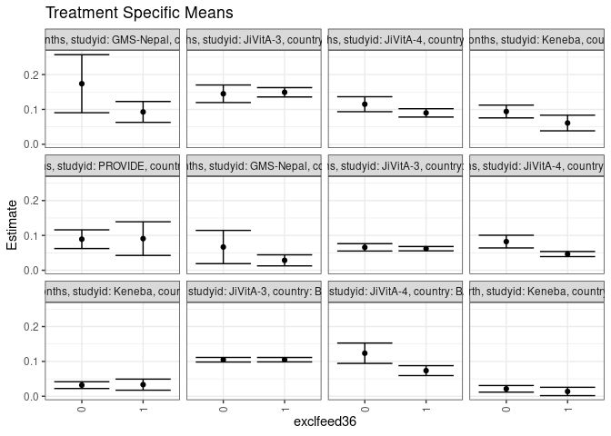

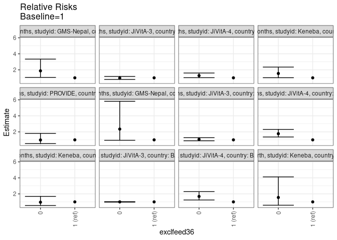

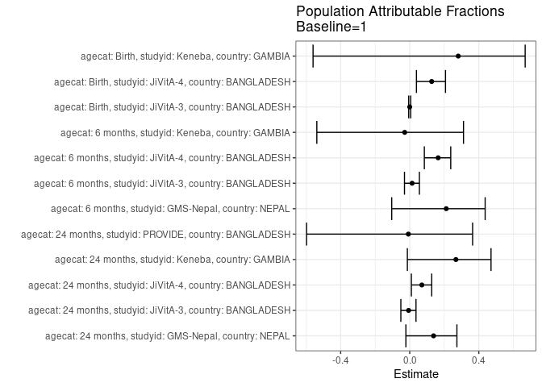

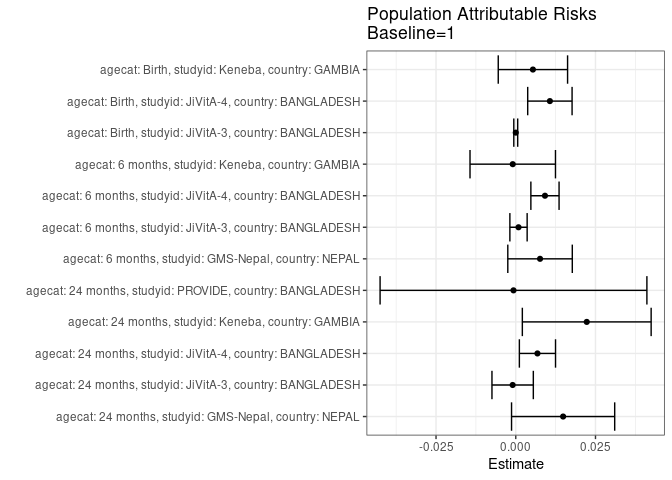

## Results Table

### Parameter: TSM

| agecat | studyid | country | intervention_level | baseline_level | estimate | ci_lower | ci_upper |
| --- | --- | --- | --- | --- | --- | --- | --- |
| Birth | JiVitA-3 | BANGLADESH | 1 | NA | 0.1049555 | 0.0985688 | 0.1113421 |
| Birth | JiVitA-3 | BANGLADESH | 0 | NA | 0.1048239 | 0.0982035 | 0.1114442 |
| Birth | JiVitA-4 | BANGLADESH | 1 | NA | 0.0735244 | 0.0592634 | 0.0877855 |
| Birth | JiVitA-4 | BANGLADESH | 0 | NA | 0.1235351 | 0.0943346 | 0.1527356 |
| Birth | Keneba | GAMBIA | 1 | NA | 0.0137741 | 0.0017794 | 0.0257688 |
| Birth | Keneba | GAMBIA | 0 | NA | 0.0213483 | 0.0118483 | 0.0308483 |
| 6 months | GMS-Nepal | NEPAL | 1 | NA | 0.0284360 | 0.0125625 | 0.0443096 |
| 6 months | GMS-Nepal | NEPAL | 0 | NA | 0.0666667 | 0.0189095 | 0.1144238 |
| 6 months | JiVitA-3 | BANGLADESH | 1 | NA | 0.0619283 | 0.0557515 | 0.0681051 |
| 6 months | JiVitA-3 | BANGLADESH | 0 | NA | 0.0657195 | 0.0551804 | 0.0762586 |
| 6 months | JiVitA-4 | BANGLADESH | 1 | NA | 0.0465158 | 0.0391812 | 0.0538504 |
| 6 months | JiVitA-4 | BANGLADESH | 0 | NA | 0.0822663 | 0.0639779 | 0.1005547 |
| 6 months | Keneba | GAMBIA | 1 | NA | 0.0333467 | 0.0174306 | 0.0492629 |
| 6 months | Keneba | GAMBIA | 0 | NA | 0.0319648 | 0.0223101 | 0.0416195 |
| 24 months | GMS-Nepal | NEPAL | 1 | NA | 0.0927724 | 0.0628554 | 0.1226893 |
| 24 months | GMS-Nepal | NEPAL | 0 | NA | 0.1737534 | 0.0904615 | 0.2570452 |
| 24 months | JiVitA-3 | BANGLADESH | 1 | NA | 0.1491079 | 0.1357256 | 0.1624902 |
| 24 months | JiVitA-3 | BANGLADESH | 0 | NA | 0.1448753 | 0.1196584 | 0.1700922 |
| 24 months | JiVitA-4 | BANGLADESH | 1 | NA | 0.0900125 | 0.0780782 | 0.1019468 |
| 24 months | JiVitA-4 | BANGLADESH | 0 | NA | 0.1149177 | 0.0934879 | 0.1363475 |
| 24 months | Keneba | GAMBIA | 1 | NA | 0.0609553 | 0.0385165 | 0.0833942 |
| 24 months | Keneba | GAMBIA | 0 | NA | 0.0940060 | 0.0756427 | 0.1123693 |
| 24 months | PROVIDE | BANGLADESH | 1 | NA | 0.0908320 | 0.0425853 | 0.1390788 |
| 24 months | PROVIDE | BANGLADESH | 0 | NA | 0.0891935 | 0.0623549 | 0.1160321 |

### Parameter: E(Y)

| agecat | studyid | country | intervention_level | baseline_level | estimate | ci_lower | ci_upper |
| --- | --- | --- | --- | --- | --- | --- | --- |
| Birth | JiVitA-3 | BANGLADESH | NA | NA | 0.1049527 | 0.0986146 | 0.1112909 |
| Birth | JiVitA-4 | BANGLADESH | NA | NA | 0.0842273 | 0.0714625 | 0.0969920 |
| Birth | Keneba | GAMBIA | NA | NA | 0.0191540 | 0.0115617 | 0.0267464 |
| 6 months | GMS-Nepal | NEPAL | NA | NA | 0.0360531 | 0.0201218 | 0.0519845 |
| 6 months | JiVitA-3 | BANGLADESH | NA | NA | 0.0627923 | 0.0572659 | 0.0683187 |
| 6 months | JiVitA-4 | BANGLADESH | NA | NA | 0.0556750 | 0.0484735 | 0.0628765 |
| 6 months | Keneba | GAMBIA | NA | NA | 0.0324022 | 0.0241972 | 0.0406072 |
| 24 months | GMS-Nepal | NEPAL | NA | NA | 0.1076233 | 0.0788298 | 0.1364169 |
| 24 months | JiVitA-3 | BANGLADESH | NA | NA | 0.1481311 | 0.1360218 | 0.1602403 |
| 24 months | JiVitA-4 | BANGLADESH | NA | NA | 0.0968140 | 0.0862351 | 0.1073930 |
| 24 months | Keneba | GAMBIA | NA | NA | 0.0832138 | 0.0687092 | 0.0977183 |
| 24 months | PROVIDE | BANGLADESH | NA | NA | 0.0901213 | 0.0667360 | 0.1135066 |

### Parameter: RR

| agecat | studyid | country | intervention_level | baseline_level | estimate | ci_lower | ci_upper |
| --- | --- | --- | --- | --- | --- | --- | --- |
| Birth | JiVitA-3 | BANGLADESH | 1 | 1 | 1.0000000 | 1.0000000 | 1.000000 |
| Birth | JiVitA-3 | BANGLADESH | 0 | 1 | 0.9987460 | 0.9728309 | 1.025351 |
| Birth | JiVitA-4 | BANGLADESH | 1 | 1 | 1.0000000 | 1.0000000 | 1.000000 |
| Birth | JiVitA-4 | BANGLADESH | 0 | 1 | 1.6801915 | 1.2374477 | 2.281344 |
| Birth | Keneba | GAMBIA | 1 | 1 | 1.0000000 | 1.0000000 | 1.000000 |
| Birth | Keneba | GAMBIA | 0 | 1 | 1.5498876 | 0.5828980 | 4.121050 |
| 6 months | GMS-Nepal | NEPAL | 1 | 1 | 1.0000000 | 1.0000000 | 1.000000 |
| 6 months | GMS-Nepal | NEPAL | 0 | 1 | 2.3444444 | 0.9454214 | 5.813725 |
| 6 months | JiVitA-3 | BANGLADESH | 1 | 1 | 1.0000000 | 1.0000000 | 1.000000 |
| 6 months | JiVitA-3 | BANGLADESH | 0 | 1 | 1.0612189 | 0.8852453 | 1.272174 |
| 6 months | JiVitA-4 | BANGLADESH | 1 | 1 | 1.0000000 | 1.0000000 | 1.000000 |
| 6 months | JiVitA-4 | BANGLADESH | 0 | 1 | 1.7685659 | 1.3581865 | 2.302942 |
| 6 months | Keneba | GAMBIA | 1 | 1 | 1.0000000 | 1.0000000 | 1.000000 |
| 6 months | Keneba | GAMBIA | 0 | 1 | 0.9585585 | 0.5449725 | 1.686020 |
| 24 months | GMS-Nepal | NEPAL | 1 | 1 | 1.0000000 | 1.0000000 | 1.000000 |
| 24 months | GMS-Nepal | NEPAL | 0 | 1 | 1.8729004 | 1.0518725 | 3.334773 |
| 24 months | JiVitA-3 | BANGLADESH | 1 | 1 | 1.0000000 | 1.0000000 | 1.000000 |
| 24 months | JiVitA-3 | BANGLADESH | 0 | 1 | 0.9716137 | 0.8024364 | 1.176459 |
| 24 months | JiVitA-4 | BANGLADESH | 1 | 1 | 1.0000000 | 1.0000000 | 1.000000 |
| 24 months | JiVitA-4 | BANGLADESH | 0 | 1 | 1.2766858 | 1.0190853 | 1.599401 |
| 24 months | Keneba | GAMBIA | 1 | 1 | 1.0000000 | 1.0000000 | 1.000000 |
| 24 months | Keneba | GAMBIA | 0 | 1 | 1.5422115 | 1.0164180 | 2.339998 |
| 24 months | PROVIDE | BANGLADESH | 1 | 1 | 1.0000000 | 1.0000000 | 1.000000 |
| 24 months | PROVIDE | BANGLADESH | 0 | 1 | 0.9819609 | 0.5331451 | 1.808602 |

### Parameter: PAR

| agecat | studyid | country | intervention_level | baseline_level | estimate | ci_lower | ci_upper |
| --- | --- | --- | --- | --- | --- | --- | --- |
| Birth | JiVitA-3 | BANGLADESH | 1 | NA | -0.0000028 | -0.0006135 | 0.0006080 |
| Birth | JiVitA-4 | BANGLADESH | 1 | NA | 0.0107028 | 0.0037449 | 0.0176608 |
| Birth | Keneba | GAMBIA | 1 | NA | 0.0053799 | -0.0054900 | 0.0162498 |
| 6 months | GMS-Nepal | NEPAL | 1 | NA | 0.0076171 | -0.0024945 | 0.0177287 |
| 6 months | JiVitA-3 | BANGLADESH | 1 | NA | 0.0008640 | -0.0018430 | 0.0035710 |
| 6 months | JiVitA-4 | BANGLADESH | 1 | NA | 0.0091592 | 0.0047374 | 0.0135810 |
| 6 months | Keneba | GAMBIA | 1 | NA | -0.0009445 | -0.0143447 | 0.0124556 |
| 24 months | GMS-Nepal | NEPAL | 1 | NA | 0.0148510 | -0.0013219 | 0.0310238 |
| 24 months | JiVitA-3 | BANGLADESH | 1 | NA | -0.0009769 | -0.0074619 | 0.0055081 |
| 24 months | JiVitA-4 | BANGLADESH | 1 | NA | 0.0068015 | 0.0011325 | 0.0124706 |
| 24 months | Keneba | GAMBIA | 1 | NA | 0.0222584 | 0.0020637 | 0.0424531 |
| 24 months | PROVIDE | BANGLADESH | 1 | NA | -0.0007107 | -0.0425431 | 0.0411217 |

### Parameter: PAF

| agecat | studyid | country | intervention_level | baseline_level | estimate | ci_lower | ci_upper |
| --- | --- | --- | --- | --- | --- | --- | --- |
| Birth | JiVitA-3 | BANGLADESH | 1 | NA | -0.0000263 | -0.0058624 | 0.0057760 |
| Birth | JiVitA-4 | BANGLADESH | 1 | NA | 0.1270708 | 0.0389206 | 0.2071358 |
| Birth | Keneba | GAMBIA | 1 | NA | 0.2808770 | -0.5597600 | 0.6684503 |
| 6 months | GMS-Nepal | NEPAL | 1 | NA | 0.2112746 | -0.1042928 | 0.4366642 |
| 6 months | JiVitA-3 | BANGLADESH | 1 | NA | 0.0137599 | -0.0303367 | 0.0559692 |
| 6 months | JiVitA-4 | BANGLADESH | 1 | NA | 0.1645120 | 0.0845921 | 0.2374545 |
| 6 months | Keneba | GAMBIA | 1 | NA | -0.0291497 | -0.5379187 | 0.3113101 |
| 24 months | GMS-Nepal | NEPAL | 1 | NA | 0.1379902 | -0.0223098 | 0.2731549 |
| 24 months | JiVitA-3 | BANGLADESH | 1 | NA | -0.0065947 | -0.0513774 | 0.0362806 |
| 24 months | JiVitA-4 | BANGLADESH | 1 | NA | 0.0702535 | 0.0093903 | 0.1273773 |
| 24 months | Keneba | GAMBIA | 1 | NA | 0.2674851 | -0.0137143 | 0.4706811 |
| 24 months | PROVIDE | BANGLADESH | 1 | NA | -0.0078859 | -0.5973953 | 0.3640685 |